# Carrefour-Marketing-Project Applying Dimensionality Reduction

Dynasty

2022-07-29

# **Introduction**

Carrefour has 13 outlets mostly located in the suburbs of Kenya’s capital city, Nairobi. Their mission is to provide our customers with quality services, products and food accessible to all across all distribution channels.

## **Problem Statement**

The project aim to inform the marketing department on the most relevant marketing strategies that will result in the highest no. of sales (total price including tax).

## **Metrics Of Success**

1. Perform data cleaning and EDA.
2. Applying method of dimensional reduction (PCA).
3. Providing insights gained from the analysis.

## **Data Understanding**

Libraries necessary

```r
library(data.table)
library(dplyr)
library(tidyverse)
```

```r
library(ggplot2)
```

Loading the data set

```r
df <- read.csv("http://bit.ly/CarreFourDataset")
```

Previewing the data set

```r
head(df)
```

```
##    Invoice.ID Branch Customer.type Gender           Product.line Unit.price
## 1 750-67-8428      A        Member Female      Health and beauty      74.69
## 2 226-31-3081      C        Normal Female Electronic accessories      15.28
## 3 631-41-3108      A        Normal   Male     Home and lifestyle      46.33
## 4 123-19-1176      A        Member   Male      Health and beauty      58.22
## 5 373-73-7910      A        Normal   Male      Sports and travel      86.31
## 6 699-14-3026      C        Normal   Male Electronic accessories      85.39
##   Quantity     Tax      Date  Time     Payment   cogs gross.margin.percentage
## 1        7 26.1415  1/5/2019 13:08     Ewallet 522.83                4.761905
## 2        5  3.8200  3/8/2019 10:29        Cash  76.40                4.761905
## 3        7 16.2155  3/3/2019 13:23 Credit card 324.31                4.761905
## 4        8 23.2880 1/27/2019 20:33     Ewallet 465.76                4.761905
## 5        7 30.2085  2/8/2019 10:37     Ewallet 604.17                4.761905
## 6        7 29.8865 3/25/2019 18:30     Ewallet 597.73                4.761905
##   gross.income Rating    Total
## 1      26.1415    9.1 548.9715
## 2       3.8200    9.6  80.2200
## 3      16.2155    7.4 340.5255
## 4      23.2880    8.4 489.0480
## 5      30.2085    5.3 634.3785
## 6      29.8865    4.1 627.6165
```

Number of records

```r
dim(df)
```

```
## [1] 1000   16
```

We have 1000 rows and 16 columns.

Checking the structure of the data set

```r
str(df)
```

```
## 'data.frame':    1000 obs. of  16 variables:
##  $ Invoice.ID             : chr  "750-67-8428" "226-31-3081" "631-41-3108" "123-19-1176" ...
##  $ Branch                 : chr  "A" "C" "A" "A" ...
##  $ Customer.type          : chr  "Member" "Normal" "Normal" "Member" ...
##  $ Gender                 : chr  "Female" "Female" "Male" "Male" ...
##  $ Product.line           : chr  "Health and beauty" "Electronic accessories" "Home and lifestyle" "Health and beauty" ...
##  $ Unit.price             : num  74.7 15.3 46.3 58.2 86.3 ...
##  $ Quantity               : int  7 5 7 8 7 7 6 10 2 3 ...
##  $ Tax                    : num  26.14 3.82 16.22 23.29 30.21 ...
##  $ Date                   : chr  "1/5/2019" "3/8/2019" "3/3/2019" "1/27/2019" ...
##  $ Time                   : chr  "13:08" "10:29" "13:23" "20:33" ...
##  $ Payment                : chr  "Ewallet" "Cash" "Credit card" "Ewallet" ...
##  $ cogs                   : num  522.8 76.4 324.3 465.8 604.2 ...
##  $ gross.margin.percentage: num  4.76 4.76 4.76 4.76 4.76 ...
##  $ gross.income           : num  26.14 3.82 16.22 23.29 30.21 ...
##  $ Rating                 : num  9.1 9.6 7.4 8.4 5.3 4.1 5.8 8 7.2 5.9 ...
##  $ Total                  : num  549 80.2 340.5 489 634.4 ...
```

We have 8 numeric columns, 5 categorical column and two columns with date/time.

## **Data Cleaning and Data Preparation**

**Checking for Missing Values**

```r
is.null(df)
```

```
## [1] FALSE
```

We don’t have Null values is the data set.

**Checking for Duplicates**

```r
duplicated_rows <- df[duplicated(df),]
duplicated_rows
```

```
##  [1] Invoice.ID              Branch                  Customer.type
##  [4] Gender                  Product.line            Unit.price
##  [7] Quantity                Tax                     Date
## [10] Time                    Payment                 cogs
## [13] gross.margin.percentage gross.income            Rating
## [16] Total
## <0 rows> (or 0-length row.names)
```

We don’t have duplicates in our data set

**Checking for Outliers**

Selecting the numeric columns

```r
num <- df[,c(6:8, 12, 14:16)]

num
```

[output not shown]

[output cut: 986 more lines]

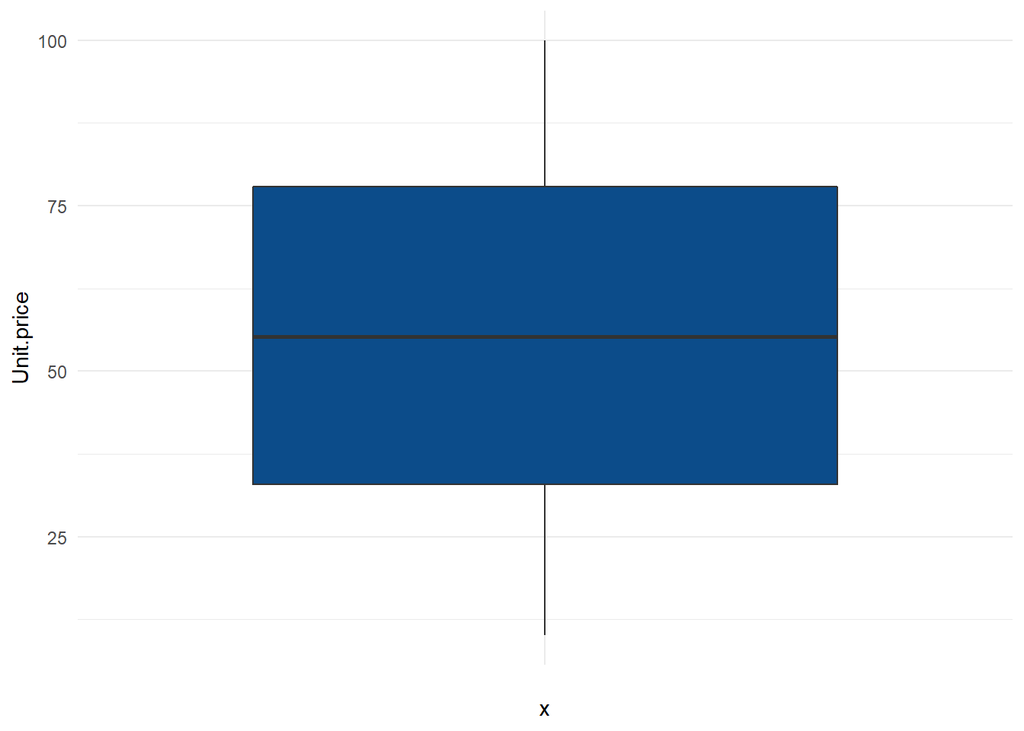

```r
ggplot(num) +
  aes(x = "", y = Unit.price) +
  geom_boxplot(fill = "#0c4c8a") +
  theme_minimal()
```

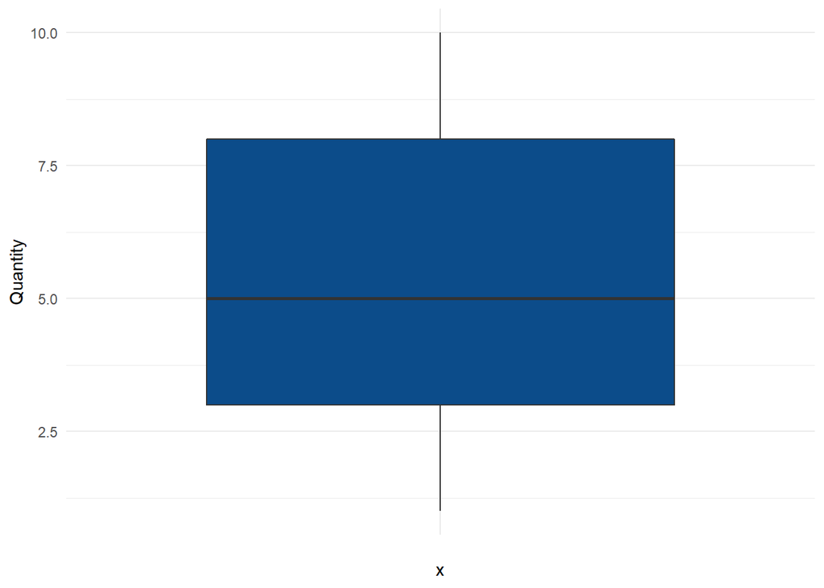

```r
ggplot(num) +
  aes(x = "", y = Quantity) +
  geom_boxplot(fill = "#0c4c8a") +
  theme_minimal()
```

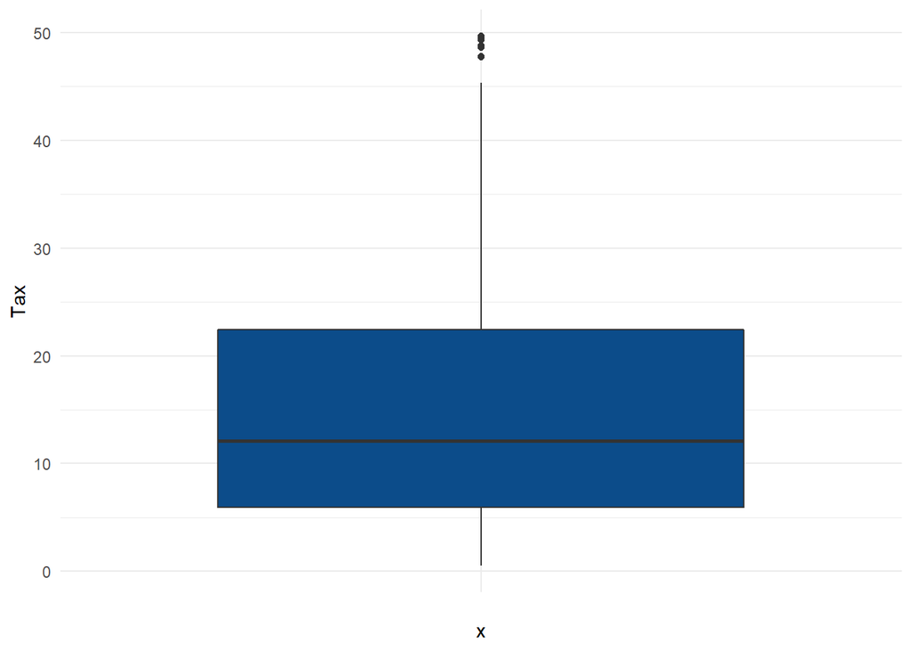

```r
ggplot(num) +
  aes(x = "", y = Tax) +
  geom_boxplot(fill = "#0c4c8a") +
  theme_minimal()
```

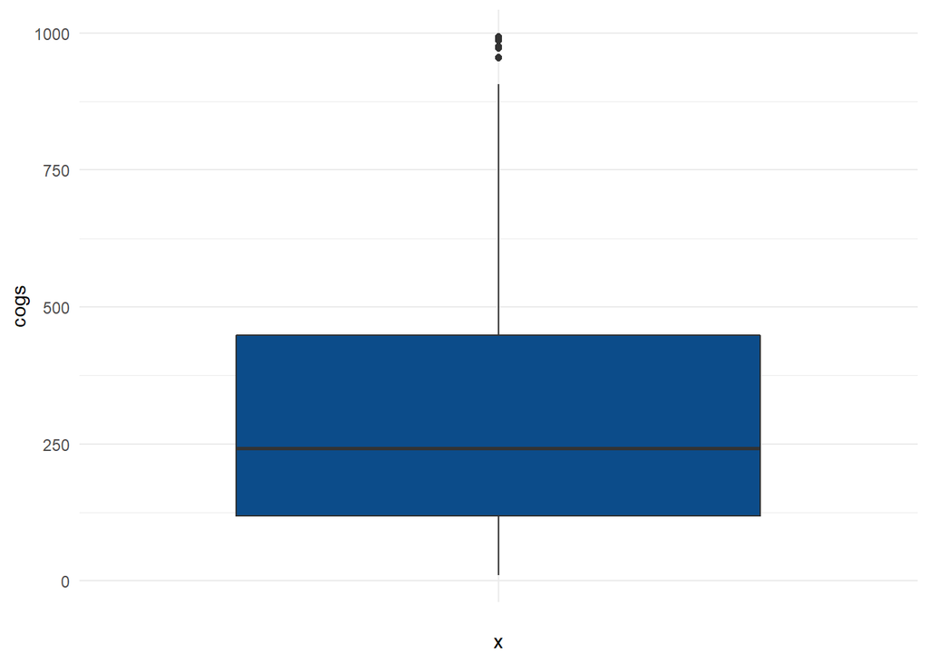

```r
ggplot(num) +
  aes(x = "", y = cogs) +
  geom_boxplot(fill = "#0c4c8a") +
  theme_minimal()
```

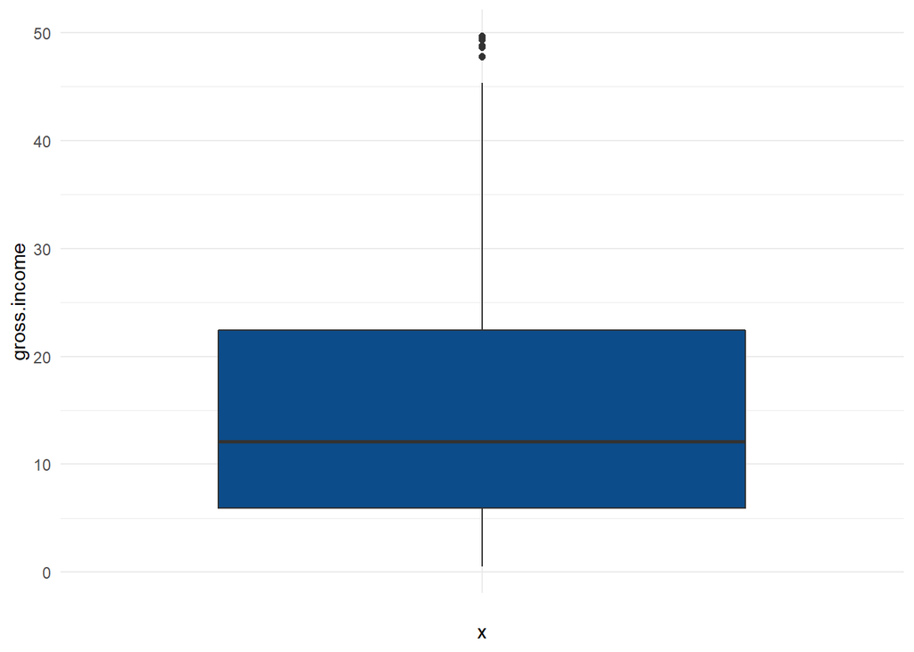

```r
ggplot(num) +
  aes(x = "", y = gross.income) +
  geom_boxplot(fill = "#0c4c8a") +
  theme_minimal()
```

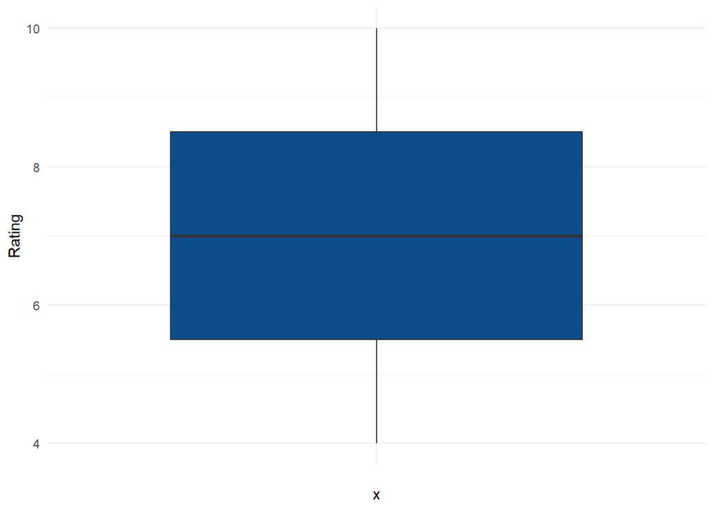

```r
ggplot(num) +
  aes(x = "", y = Rating) +
  geom_boxplot(fill = "#0c4c8a") +
  theme_minimal()
```

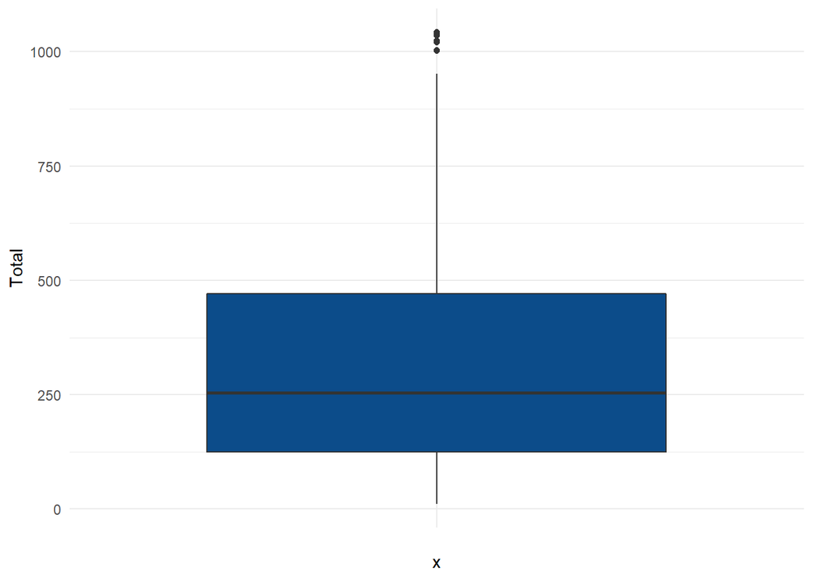

```r
ggplot(num) +
  aes(x = "", y = Total) +
  geom_boxplot(fill = "#0c4c8a") +
  theme_minimal()
```

The box plots above clearly indicate we have a few outliers in Tax, cogs, gross.income and total column. However, they are important for our analysis so will keep them for now

# **Exploratory Data Analysis**

### **Univariate Analysis**

Previewing branch distribution

```r
branch <- (df$Branch)
branch.frequency <- table(branch)
branch.frequency
```

```
## branch
##   A   B   C
## 340 332 328
```

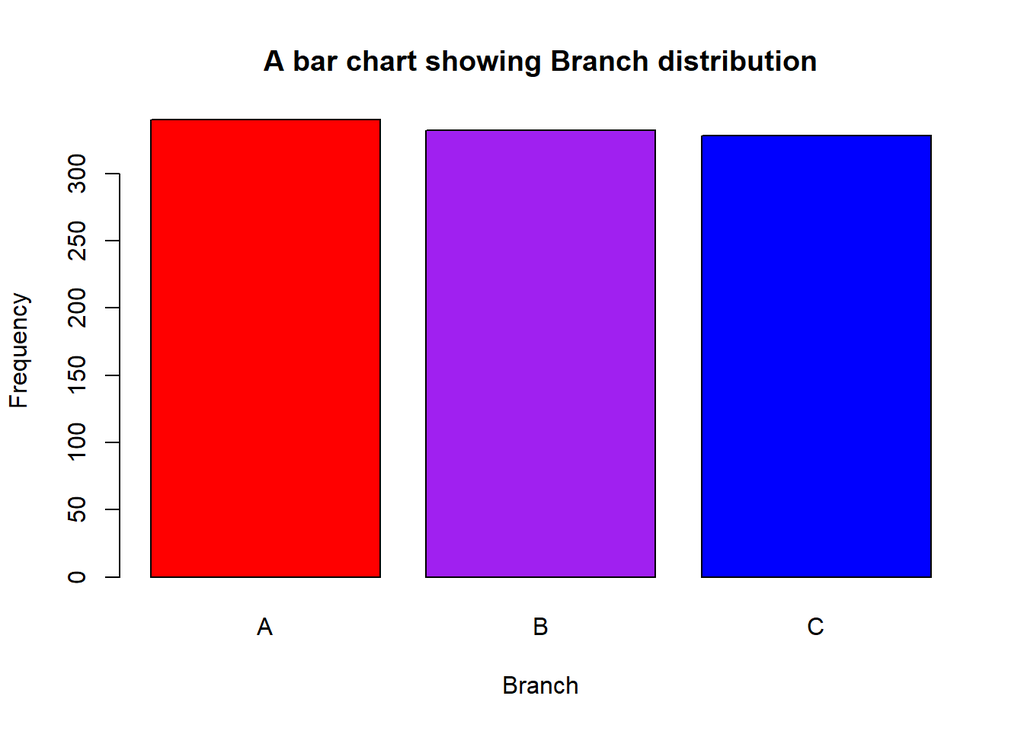

```r
barplot(branch.frequency,
  main="A bar chart showing Branch distribution",
  xlab="Branch",
  ylab = "Frequency",
  col=c("red","purple", "blue"),
  )
```

The bar graph above shows Branch A had the highest distribution with Brach c with the least even though the differences was very minimal.

Previewing Product line distribution

```r
pl <- (df$Product.line)
pl.frequency <- table(pl)
pl.frequency
```

```
## pl
## Electronic accessories    Fashion accessories     Food and beverages
##                    170                    178                    174
##      Health and beauty     Home and lifestyle      Sports and travel
##                    152                    160                    166
```

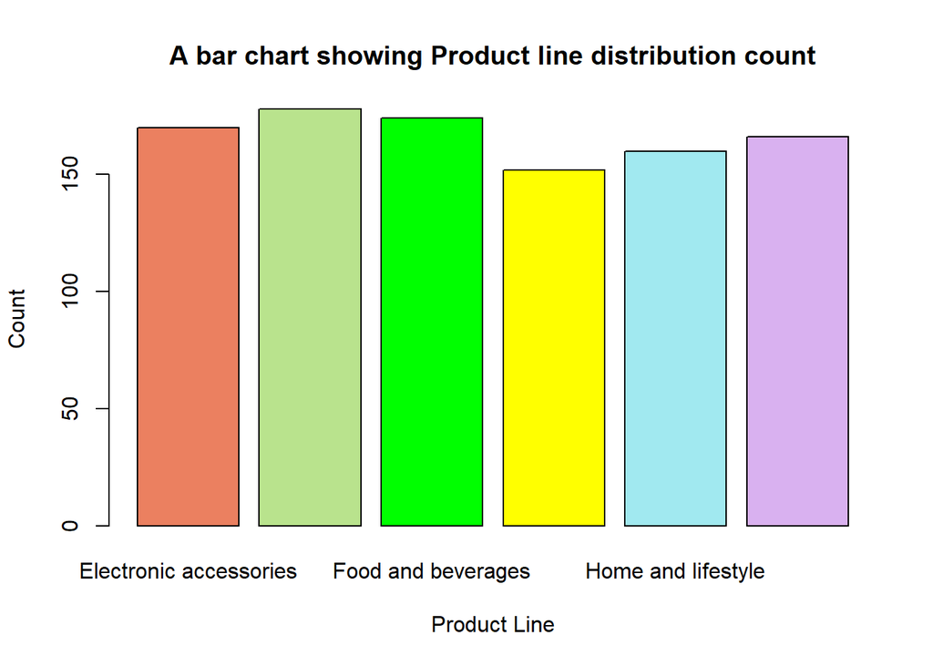

```r
barplot(pl.frequency,
  main="A bar chart showing Product line distribution count",
  xlab="Product Line",
  ylab = "Count",
  col=c("#eb8060", "#b9e38d", "green", "yellow", "#a1e9f0", "#d9b1f0"),
  )
```

Most sales were from Fashion accessories product line while least sales were from Health and beauty product line.

Previewing Customer type Distribution

```r
cust <- (df$Customer.type)
cust.frequency <- table(cust)
cust.frequency
```

```
## cust
## Member Normal
##    501    499
```

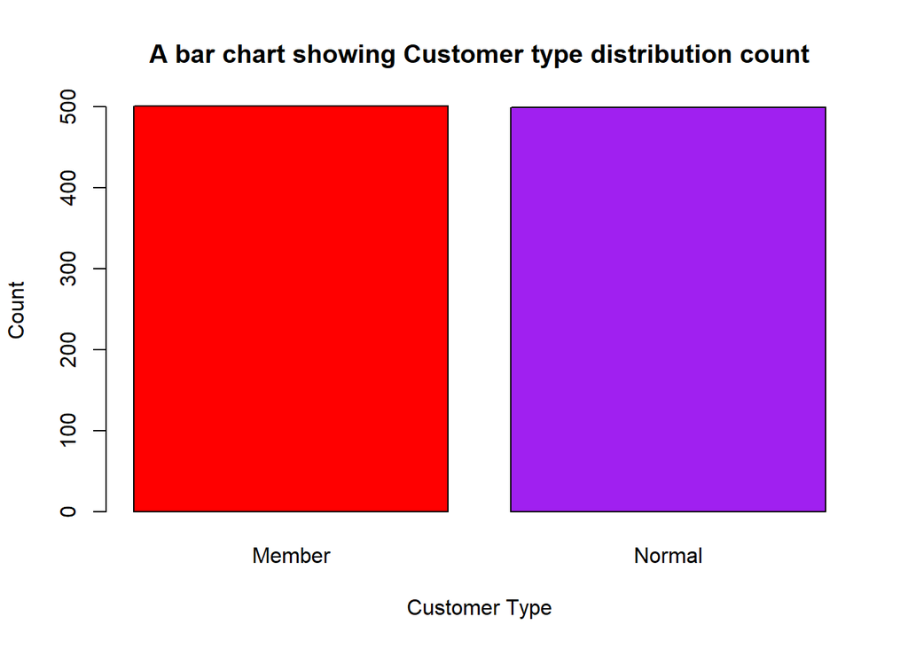

```r
barplot(cust.frequency,
  main="A bar chart showing Customer type distribution count",
  xlab="Customer Type",
  ylab = "Count",
  col=c("red","purple"),
  )
```

Most customer were members customers.

Previewing Gender distribution

```r
gender <- (df$Gender)
gender.frequency <- table(gender)
gender.frequency
```

```
## gender
## Female   Male
##    501    499
```

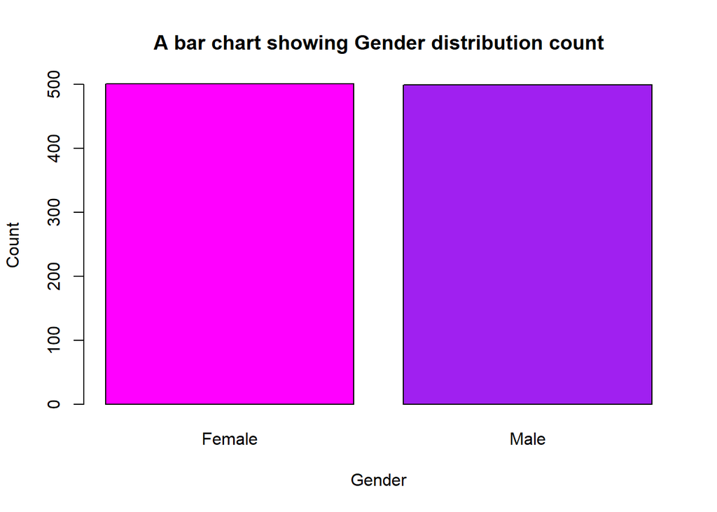

```r
barplot(gender.frequency,
  main="A bar chart showing Gender distribution count",
  xlab="Gender",
  ylab = "Count",
  col=c("magenta","purple"),
  )
```

Most customers were female

Previewing payment methods

```r
payment <- (df$Payment)
payment.frequency <- table(payment)
payment.frequency
```

```
## payment
##        Cash Credit card     Ewallet
##         344         311         345
```

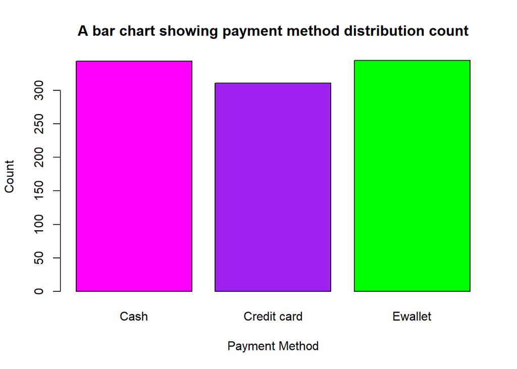

```r
barplot(payment.frequency,
  main="A bar chart showing payment method distribution count",
  xlab="Payment Method",
  ylab = "Count",
  col=c("magenta","purple", "green"),
  )
```

Most customers use Ewallet and least payment method used by customers is via credit card.

Previewing Unit prices distribution

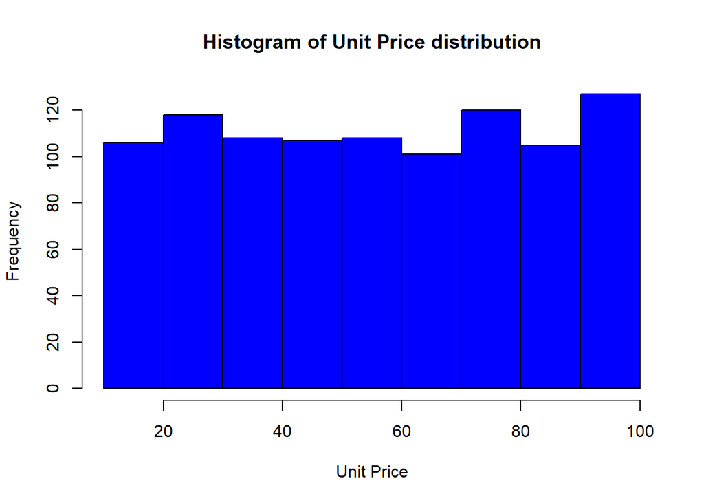

```r
hist((df$Unit.price),
main = "Histogram of Unit Price distribution",
     xlab = 'Unit Price',
     ylab = 'Frequency',
     col = "blue")
```

Maximum unit prices were around 100.

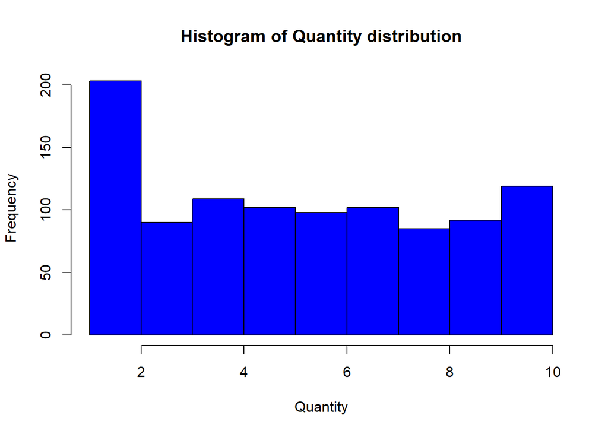

```r
hist((df$Quantity),
main = "Histogram of Quantity distribution",
     xlab = 'Quantity',
     ylab = 'Frequency',
     col = "blue")
```

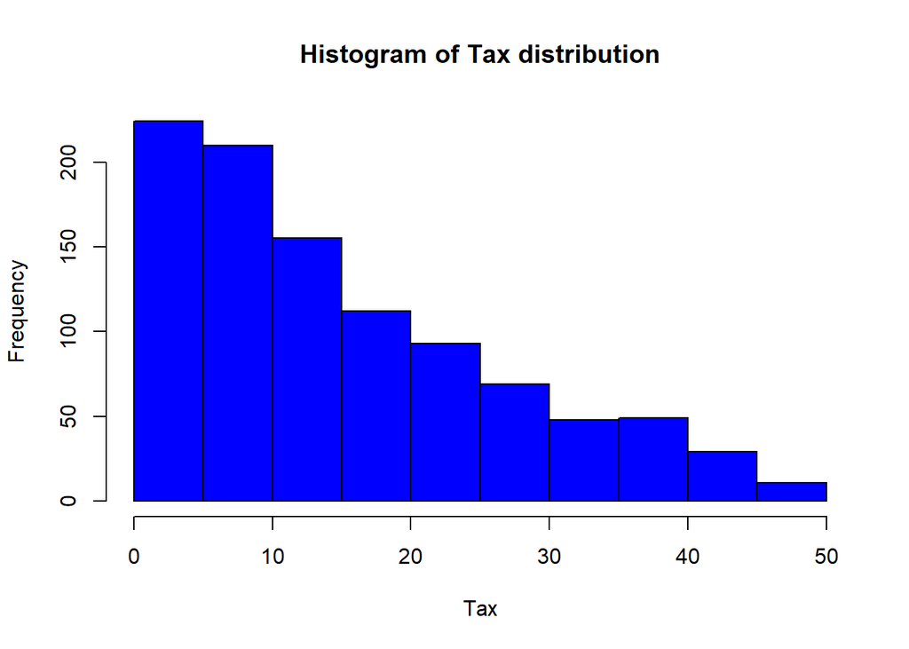

```r
hist((df$Tax),
main = "Histogram of Tax distribution",
     xlab = 'Tax',
     ylab = 'Frequency',
     col = "blue")
```

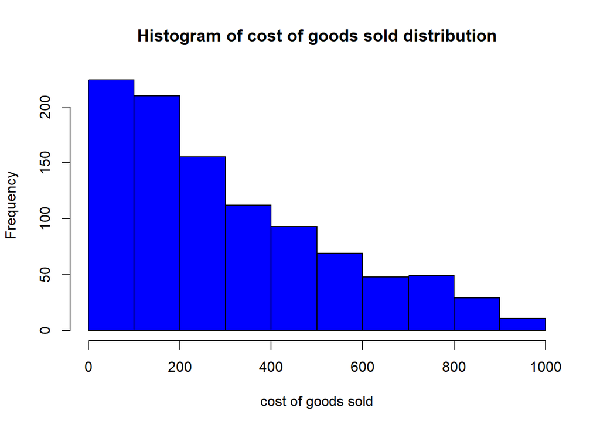

```r
hist((df$cogs),
main = "Histogram of cost of goods sold distribution",
     xlab = 'cost of goods sold',
     ylab = 'Frequency',
     col = "blue")
```

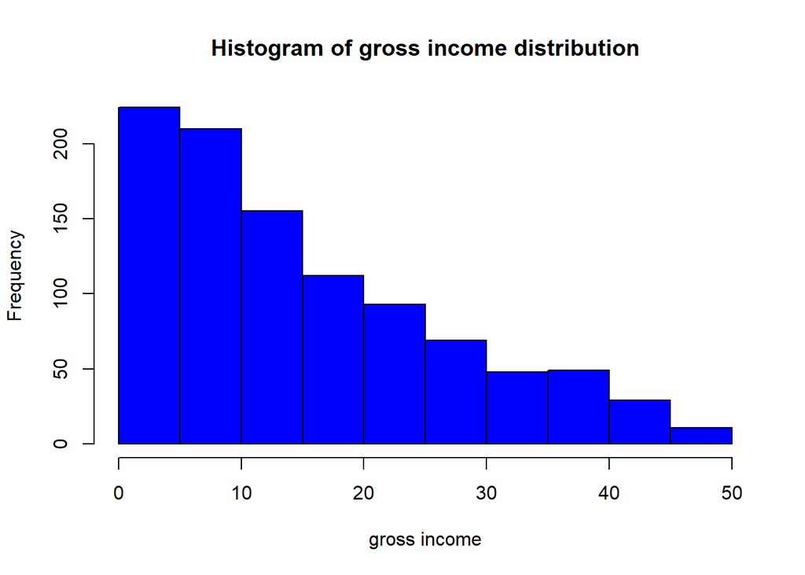

```r
hist((df$gross.income),
main = "Histogram of gross income distribution",
     xlab = 'gross income',
     ylab = 'Frequency',
     col = "blue")
```

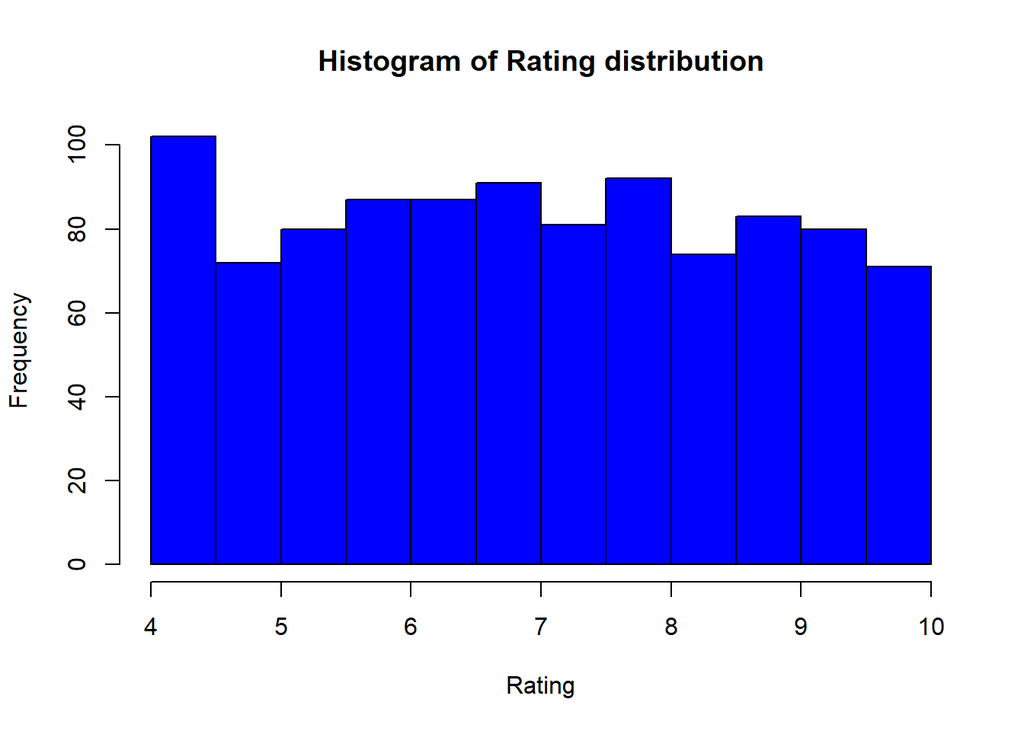

```r
hist((df$Rating),
main = "Histogram of Rating distribution",
     xlab = 'Rating',
     ylab = 'Frequency',
     col = "blue")
```

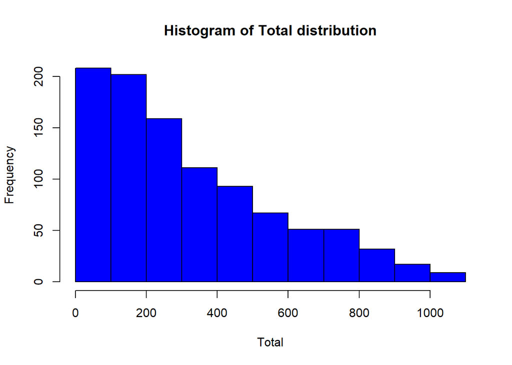

```r
hist((df$Total),
main = "Histogram of Total distribution",
     xlab = 'Total',
     ylab = 'Frequency',
     col = "blue")
```

### **Bivariate Analysis**

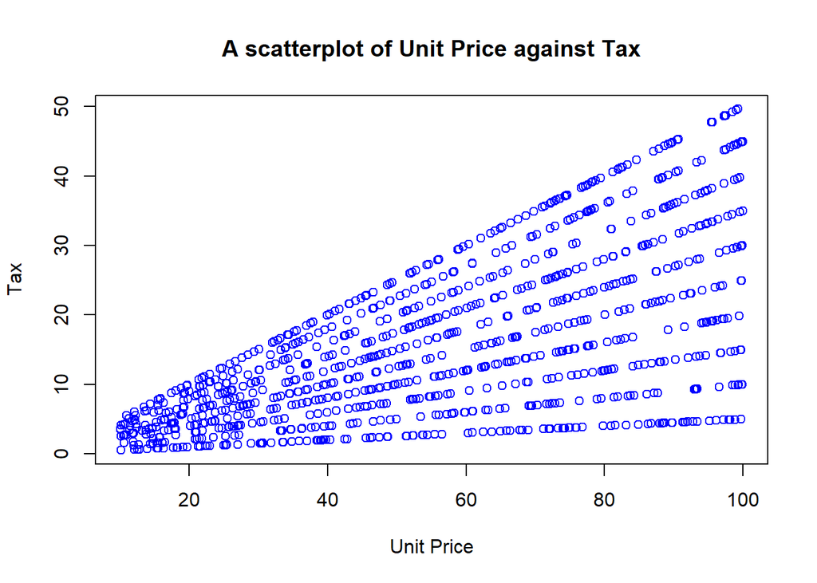

```r
plot((df$Unit.price), (df$Tax),
     main = "A scatterplot of Unit Price against Tax",
     xlab = 'Unit Price',
     ylab = 'Tax',
     col = "blue")
```

The higher the unit price the higher the tax applied

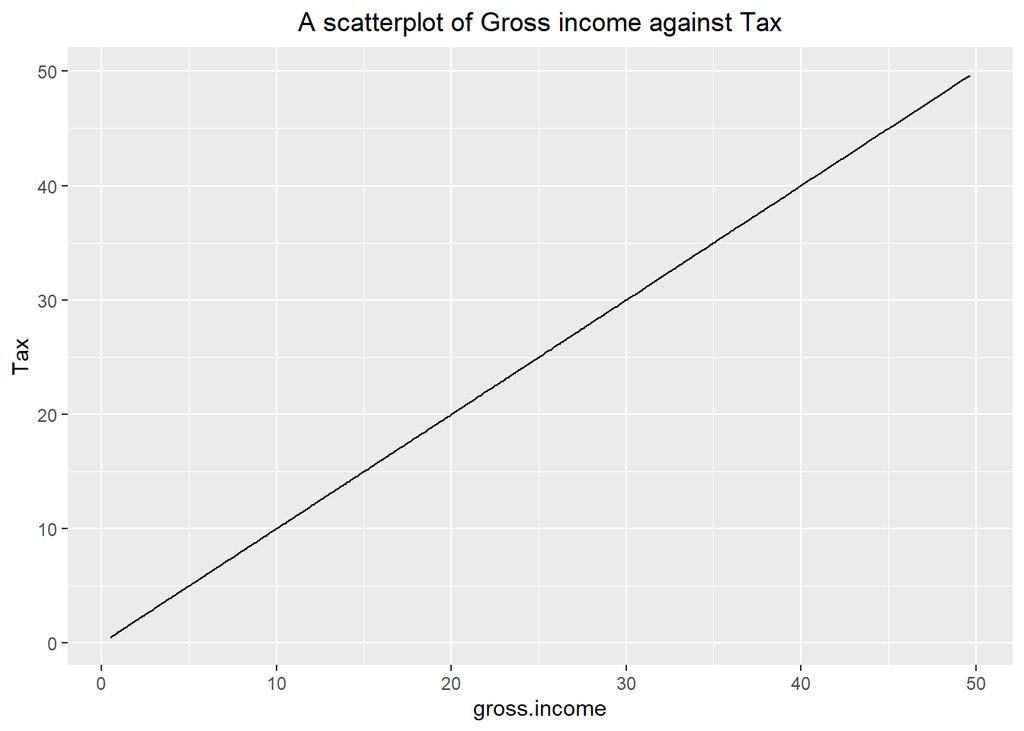

```r
ggplot(df,aes(x=gross.income, y=Tax))+geom_line()+
ggtitle("A scatterplot of Gross income against Tax")+
theme(plot.title = element_text(hjust=0.5))
```

Tax increases with increase in Gross income.

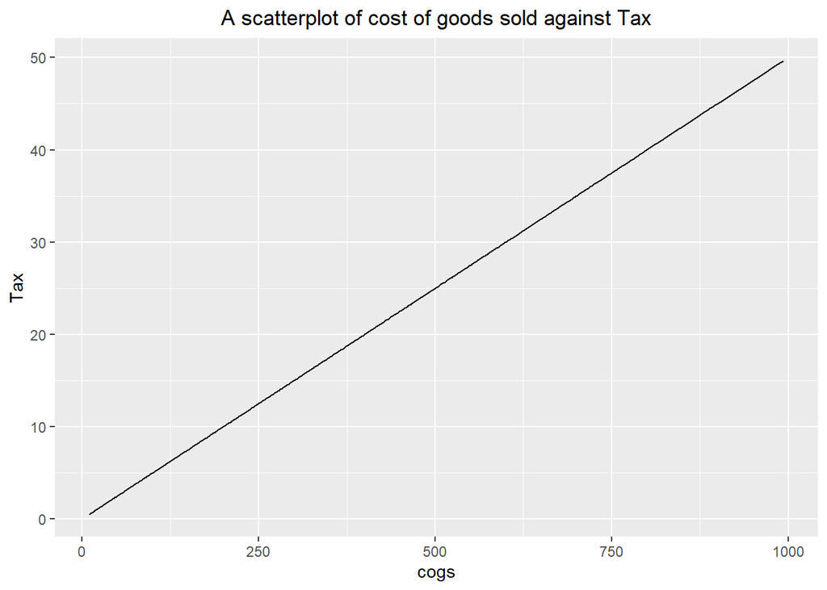

```r
ggplot(df,aes(x=cogs, y=Tax))+geom_line()+
ggtitle("A scatterplot of cost of goods sold against Tax")+
theme(plot.title = element_text(hjust=0.5))
```

The higher the cost of goods sold the tax increases.

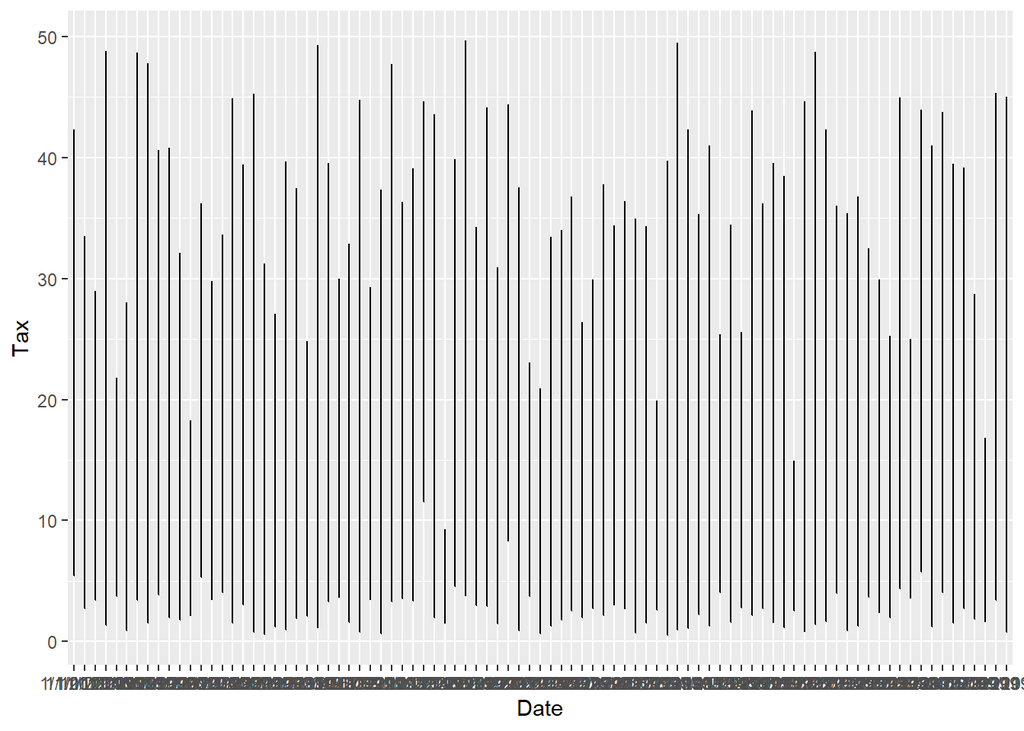

```r
ggplot(df,aes(x=Date, y=Tax))+geom_line()
```

Tax has been increasing and decreasing over time

### **Multivariate Analysis**

getting a summary for the data set from our numeric columns

```r
summary(num)
```

```
##    Unit.price       Quantity          Tax               cogs
##  Min.   :10.08   Min.   : 1.00   Min.   : 0.5085   Min.   : 10.17
##  1st Qu.:32.88   1st Qu.: 3.00   1st Qu.: 5.9249   1st Qu.:118.50
##  Median :55.23   Median : 5.00   Median :12.0880   Median :241.76
##  Mean   :55.67   Mean   : 5.51   Mean   :15.3794   Mean   :307.59
##  3rd Qu.:77.94   3rd Qu.: 8.00   3rd Qu.:22.4453   3rd Qu.:448.90
##  Max.   :99.96   Max.   :10.00   Max.   :49.6500   Max.   :993.00
##   gross.income         Rating           Total
##  Min.   : 0.5085   Min.   : 4.000   Min.   :  10.68
##  1st Qu.: 5.9249   1st Qu.: 5.500   1st Qu.: 124.42
##  Median :12.0880   Median : 7.000   Median : 253.85
##  Mean   :15.3794   Mean   : 6.973   Mean   : 322.97
##  3rd Qu.:22.4453   3rd Qu.: 8.500   3rd Qu.: 471.35
##  Max.   :49.6500   Max.   :10.000   Max.   :1042.65
```

We can observe the following: a. The maximum unit price was 99.96 and the minimum was 10.08. b. The maximum quantity ordered was 10 while the minimum was 1. c. The highest Tax applied was 49.65 while the least was 0.5. d. The highest rating was 10 while the least rating was 4.

Ploting a correlation plot

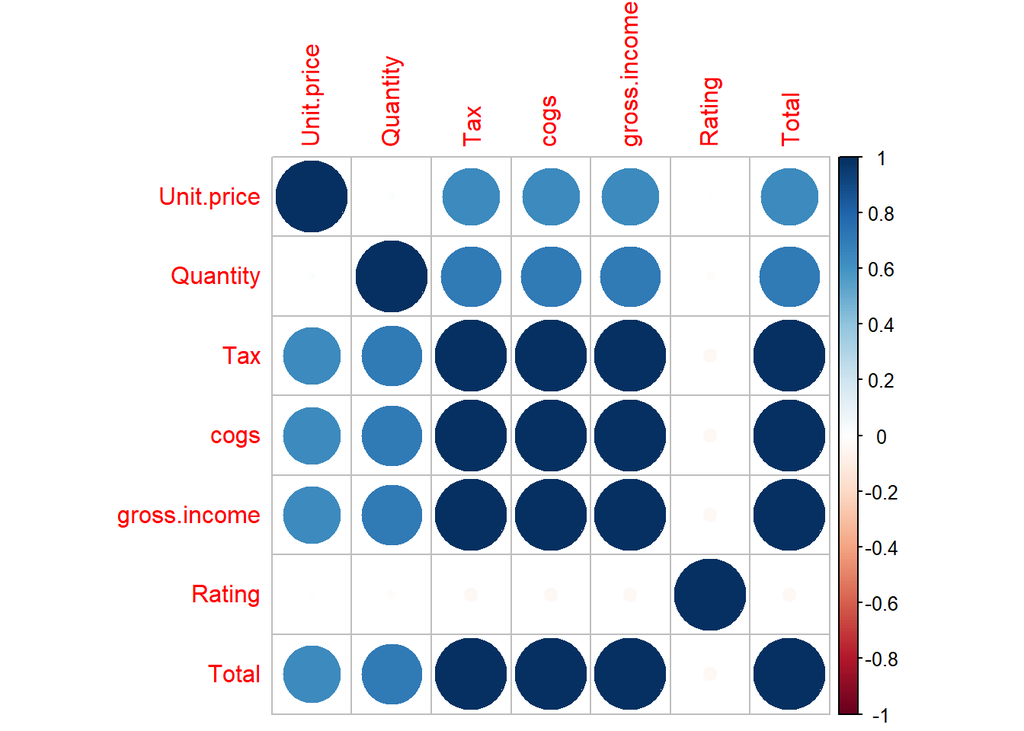

```r
library(corrplot)
corrplot(cor(num))
```

From the graph we observe:

1. Tax had a very strong correlation with cogs, gross.income and total and vice versa.

# **Dimensional Reduction**

## **1. PCA**

Apply PCA to our numeric columns

```r
my_pca <- prcomp(num, scale = TRUE,
                center = TRUE, retx = T)
summary(my_pca)
```

```
## Importance of components:
##                           PC1    PC2    PC3     PC4       PC5       PC6
## Standard deviation     2.2185 1.0002 0.9939 0.30001 2.981e-16 1.493e-16
## Proportion of Variance 0.7031 0.1429 0.1411 0.01286 0.000e+00 0.000e+00
## Cumulative Proportion  0.7031 0.8460 0.9871 1.00000 1.000e+00 1.000e+00
##                              PC7
## Standard deviation     9.831e-17
## Proportion of Variance 0.000e+00
## Cumulative Proportion  1.000e+00
```

We can see we have 7 Principal components. PC1 explains 70% of the total variance, which means that nearly three quarters of the information in the data set can be encapsulated by just that one Principal Component. PC2 explains 14% of the variance. and we can see that PCA values decrease as you go down the number of principals components. Cumulatively we see PC1 to PC3 have a proportion of 98.71% which tell us that it’s safe to say that we can fully understand this data set using only these three principal components.

```r
str(my_pca)
```

```
## List of 5
##  $ sdev    : num [1:7] 2.22 1.00 9.94e-01 3.00e-01 2.98e-16 ...
##  $ rotation: num [1:7, 1:7] -0.292 -0.325 -0.45 -0.45 -0.45 ...
##   ..- attr(*, "dimnames")=List of 2
##   .. ..$ : chr [1:7] "Unit.price" "Quantity" "Tax" "cogs" ...
##   .. ..$ : chr [1:7] "PC1" "PC2" "PC3" "PC4" ...
##  $ center  : Named num [1:7] 55.67 5.51 15.38 307.59 15.38 ...
##   ..- attr(*, "names")= chr [1:7] "Unit.price" "Quantity" "Tax" "cogs" ...
##  $ scale   : Named num [1:7] 26.49 2.92 11.71 234.18 11.71 ...
##   ..- attr(*, "names")= chr [1:7] "Unit.price" "Quantity" "Tax" "cogs" ...
##  $ x       : num [1:1000, 1:7] -2.005 2.306 -0.186 -1.504 -2.8 ...
##   ..- attr(*, "dimnames")=List of 2
##   .. ..$ : NULL
##   .. ..$ : chr [1:7] "PC1" "PC2" "PC3" "PC4" ...
##  - attr(*, "class")= chr "prcomp"
```

View the principal component loading

```r
my_pca$rotation
```

```
##                      PC1          PC2          PC3         PC4           PC5
## Unit.price   -0.29176275  0.270866890 -0.693584569  0.60037161  6.582429e-16
## Quantity     -0.32452880 -0.212748396  0.633152868  0.66972877  7.430508e-16
## Tax          -0.44977957  0.004196356  0.001836202 -0.21835146 -8.277641e-01
## cogs         -0.44977957  0.004196356  0.001836202 -0.21835146  9.549992e-02
## gross.income -0.44977957  0.004196356  0.001836202 -0.21835146  2.290536e-01
## Rating        0.01867926  0.938775165  0.343575909 -0.01754621 -1.194541e-17
## Total        -0.44977957  0.004196356  0.001836202 -0.21835146  5.032105e-01
##                        PC6           PC7
## Unit.price    5.894232e-17 -7.635490e-17
## Quantity      1.864419e-16 -1.721827e-16
## Tax           1.656386e-02  2.540320e-01
## cogs         -5.810190e-01 -6.350565e-01
## gross.income  7.836445e-01 -2.888526e-01
## Rating        1.850076e-17 -7.208985e-17
## Total        -2.191893e-01  6.698770e-01
```

Positive loading indicate a variable and a principal component are positively correlated: an increase in one results in an increase in the other. Negative loading indicate a negative correlation. Large (either positive or negative) loading indicate that a variable has a strong effect on that principal component.

See the principal components

```r
dim(my_pca$x)
```

```
## [1] 1000    7
```

Plotting our PCA

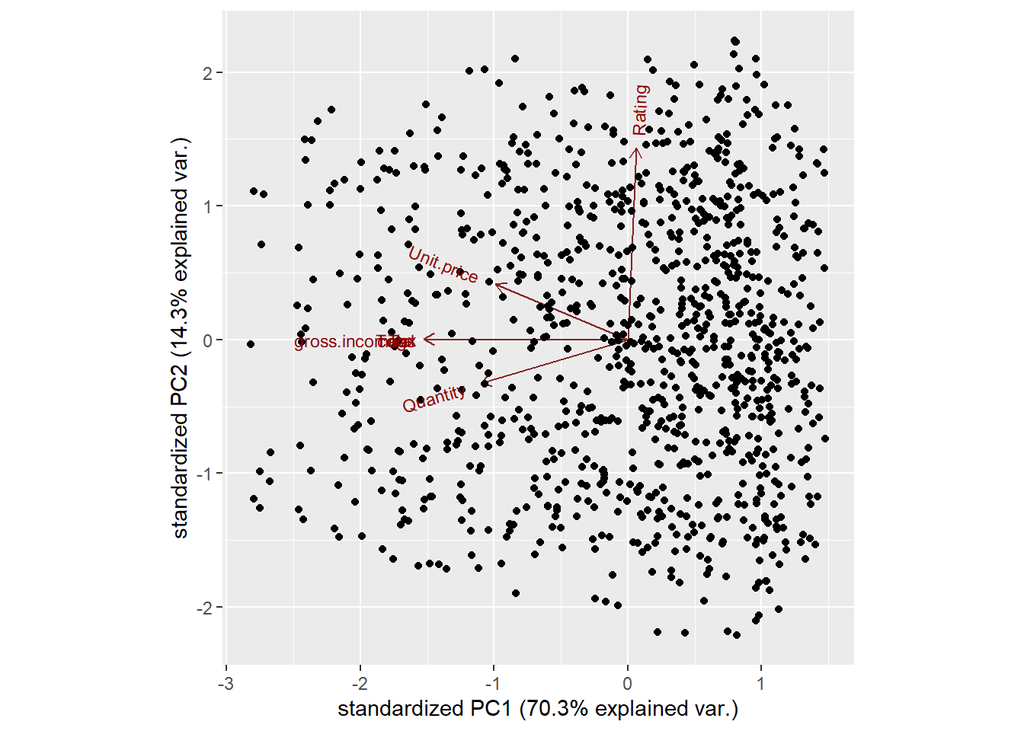

```r
library(ggbiplot)
ggbiplot(my_pca)
```

adding more details

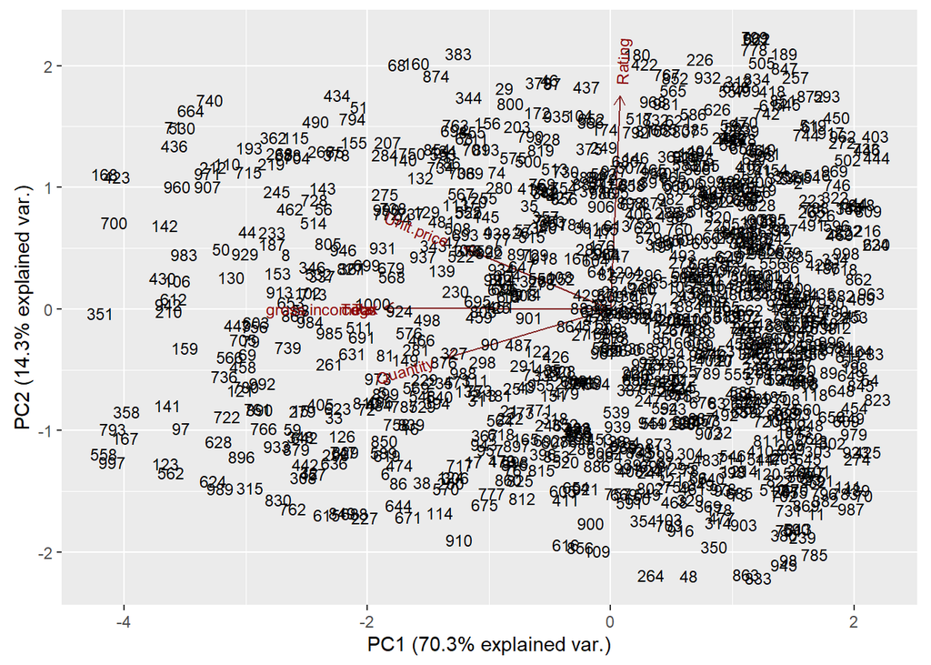

```r
ggbiplot(my_pca, labels=rownames(df), obs.scale = 0.5, var.scale = 1)
```

We have more factors but still our key attributites for analysis are still Rating, Unit.price, Quantity and gross.income

Compute standard deviation

```r
my_pca$sdev
```

```
## [1] 2.218512e+00 1.000200e+00 9.938793e-01 3.000112e-01 2.981082e-16
## [6] 1.492941e-16 9.831064e-17
```

From this we see the standard deviation decreases with numberof principal components.

Compute variance

```r
my_pca.var <- my_pca$sdev ^ 2
my_pca.var
```

```
## [1] 4.921797e+00 1.000400e+00 9.877961e-01 9.000673e-02 8.886850e-32
## [6] 2.228874e-32 9.664981e-33
```

Viewing Proportion of variance for a scree plot

```r
propve <- my_pca.var / sum(my_pca.var)
propve
```

```
## [1] 7.031139e-01 1.429143e-01 1.411137e-01 1.285810e-02 1.269550e-32
## [6] 3.184106e-33 1.380712e-33
```

Plot variance explained for each principal component

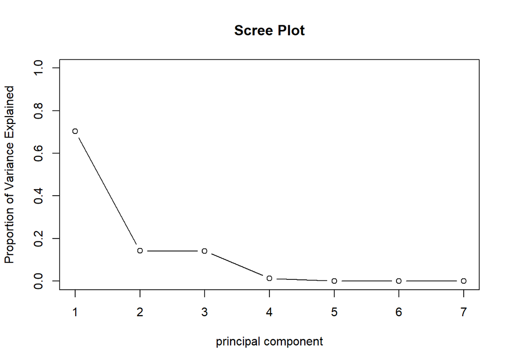

```r
plot(propve, xlab = "principal component",
            ylab = "Proportion of Variance Explained",
            ylim = c(0, 1), type = "b",
            main = "Scree Plot")
```

The graph shows the eigenvalues of factors of principal components in our analysis. It shows that below 2 principal components, there is a maximum proportion of variance as clearly seen in the plot, Meaning it can be used to determine the number of principal components to keep in our analysis in this case PC1.

Plot the cumulative proportion of variance explained

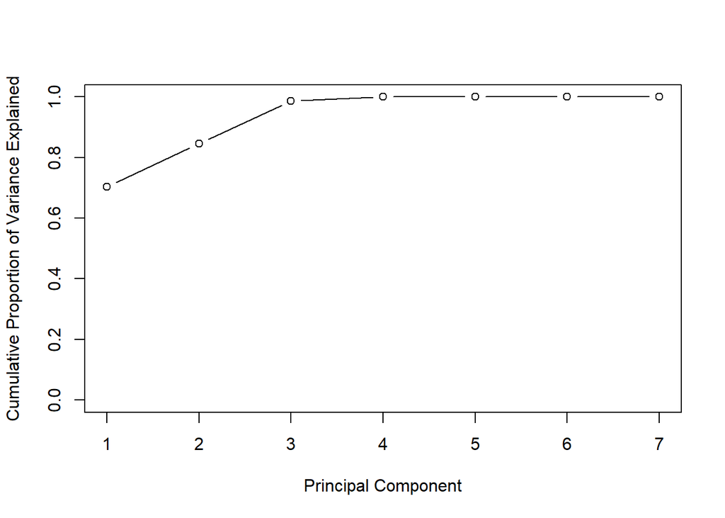

```r
plot(cumsum(propve),
    xlab = "Principal Component",
    ylab = "Cumulative Proportion of Variance Explained",
    ylim = c(0, 1), type = "b")
```

The graph shows Above 2 principal components, there is a maximum cumulative proportion of variance as clearly seen in the plot.

**Conclusion**

- We can confidently advise Carrefour marketing department on coming up with the most relevant marketing strategies they should consider unit.price, Rating, Quantity and gross.Income